# Projet d’été : déterminant de l’arrêt lors d’une RI sur Internet

Exploration d’une nouvelle heuristique décisionnelle

# A propos

- Ce projet a été réalisée à partir des résultats de trois études indépendantes menées en France, dans des collèges et lycées du Sud de la France (ville de Bordeaux, étude 1 et 2) et de l’Est (ville de Reims, étude 3) entre 2018 et 2021. Ces études ont été éffectuées en partenariat avec les rectorats des deux académies, et sous la direction du laboratoire CLLE (Université Jean Jaurès, UMR CNRS 5263).
- Pour toute information sur les données, la signification des variables, se repporter au fichier README et à la notice d’accompagnement fournis dans le repository : https://github.com/FMG-Thesa/SumProj_DUDA

# Construction du jeu de données pour tester l’heuristique

Les fichiers disponibles sont des fichiers intermédiaires, i.e préparés pour être compatibles entre eux (pas les fichiers bruts issus de la collecte directe des données). Ils ne possèdent pas le même nombre d’observations, mais possède le même nombres de caractéristiques (facteurs).

```r
library(tidyverse)
library(ggplot2)
library(dplyr)
library(ggExtra)
library(ggpubr)
```

```r
# % de NA par variable
variable_details <- function(data) {
    n_observations <- nrow(data)
    df <- data.frame(
        Type = sapply(data, class),
        Missing_Percent = sapply(data, function(x) sum(is.na(x)) / n_observations * 100)
    )
     return(df)
}
```

```r
# Thème personnel
blue_theme <- function() {
  theme(
    # add border
    panel.border = element_rect(colour = "blue", fill = NA, linetype = 2),
    # color background
    panel.background = element_rect(fill = "aliceblue"),
    # modify grid
    panel.grid.major.x = element_line(colour = "steelblue", linetype = 3, linewidth = 0.5),
    panel.grid.minor.x = element_blank(),
    panel.grid.major.y =  element_line(colour = "steelblue", linetype = 3, linewidth = 0.5),
    panel.grid.minor.y = element_blank(),
    # modify text, axis and colour
    axis.text = element_text(colour = "steelblue", face = "italic"),
    axis.title = element_text(colour = "steelblue"),
    axis.ticks = element_line(colour = "steelblue"),
    # text elements
    plot.title = element_text(size = 16, face = 'bold', hjust = 0, vjust = 2, color="steelblue"),
    plot.subtitle = element_text(size = 12),
    plot.caption = element_text(size = 9, hjust = 1),
    # legend at the bottom
    legend.position = "bottom"
  )
}
```

## Validation des données

### Etude1

Deux variables vides FOD et FOFG, comme dans la spécification des données, pas d’autres valeurs manquantes. Il n’est donc pas possible de les imputer en l’état des données disponibles. Notons que le type des variables FOF a été modifié pour rester compatible avec la fusion des jeux de données. Certaines variables affichent cependant des types qu’il est possible de modifier pour faciliter les traitement ultérieurs (variable qualitative/catégorielle de type caractère au lieu de facteur). Ils seront globalement corrigés après la concaténation.

```r
# Chargement des données etude 1
etu1 <- read.csv("expe1.csv", header = TRUE, sep=",", dec=".")
summary(etu1)
```

```
##    Domaine           Specialite         Expertise          Complexite
##  Length:228         Length:228         Length:228         Length:228
##  Class :character   Class :character   Class :character   Class :character
##  Mode  :character   Mode  :character   Mode  :character   Mode  :character
##
##
##
##     Tps_Tot         Tps_Xplr        Tps_Xplo         Tps_RI
##  Min.   :4.665   Min.   :3.491   Min.   :3.556   Min.   :3.888
##  1st Qu.:5.395   1st Qu.:4.452   1st Qu.:4.840   1st Qu.:5.083
##  Median :5.603   Median :4.846   Median :5.184   Median :5.334
##  Mean   :5.543   Mean   :4.748   Mean   :5.074   Mean   :5.279
##  3rd Qu.:5.741   3rd Qu.:5.146   3rd Qu.:5.438   3rd Qu.:5.627
##  Max.   :6.112   Max.   :5.678   Max.   :5.849   Max.   :6.044
##       SW2a             SW2b             Docs            TG_Tot
##  Min.   : 1.000   Min.   :0.0000   Min.   : 1.000   Min.   :0.000000
##  1st Qu.: 2.500   1st Qu.:0.0000   1st Qu.: 2.000   1st Qu.:0.008463
##  Median : 4.000   Median :0.5000   Median : 3.000   Median :0.017458
##  Mean   : 4.803   Mean   :0.8684   Mean   : 3.399   Mean   :0.042668
##  3rd Qu.: 7.000   3rd Qu.:1.0000   3rd Qu.: 4.500   3rd Qu.:0.032726
##  Max.   :15.000   Max.   :5.0000   Max.   :11.000   Max.   :0.555787
##    FOFG           FOFD              SAE           Eleve
##  Mode:logical   Mode:logical   Min.   :19.00   Length:228
##  NA's:228       NA's:228       1st Qu.:39.00   Class :character
##                                Median :41.50   Mode  :character
##                                Mean   :41.13
##                                3rd Qu.:45.00
##                                Max.   :49.00
```

```r
tab0_str <- capture.output(print(summary(etu1)))
writeClipboard(tab0_str)
```

```r
head(etu1)
```

|  | Domaine | Specialite | Expertise | Complexite | Tps_Tot | Tps_Xplr | Tps_Xplo | Tps_RI | SW2a | SW2b | Docs | TG_Tot | FOFG | FOFD | SAE | Eleve |
| --- | --- | --- | --- | --- | --- | --- | --- | --- | --- | --- | --- | --- | --- | --- | --- | --- |
| 1 | HIST | 3EME | expert | TC | 5.507825 | 4.403172 | 5.144327 | 5.216756 | 3.5 | 0.0 | 4.5 | 0.02869018 | NA | NA | 19 | ALE3A |
| 2 | HIST | 3EME | expert | TC | 5.153318 | 4.913522 | 4.147553 | 4.982231 | 4.0 | 0.0 | 1.0 | 0.14238929 | NA | NA | 45 | ALI3C |
| 3 | HIST | 3EME | expert | TC | 5.209855 | 4.858940 | 4.697378 | 5.086659 | 3.0 | 0.0 | 2.0 | 0.04014694 | NA | NA | 33 | ANAEL3A |
| 4 | HIST | 3EME | expert | TC | 5.577592 | 4.270306 | 4.996023 | 5.070859 | 2.0 | 0.5 | 1.5 | 0.04036795 | NA | NA | 45 | Anna3B |
| 5 | HIST | 3EME | expert | TC | 4.678682 | 3.832573 | 3.942058 | 4.191786 | 1.0 | 0.0 | 1.0 | 0.22854531 | NA | NA | 45 | CHLOE23 |
| 6 | HIST | 3EME | expert | TC | 4.978833 | 4.481471 | 4.555252 | 4.820956 | 1.0 | 0.0 | 1.0 | 0.05569014 | NA | NA | 39 | EMM23A |

```r
variable_details(etu1)
```

|  | Type | Missing_Percent |
| --- | --- | --- |
| Domaine | character | 0 |
| Specialite | character | 0 |
| Expertise | character | 0 |
| Complexite | character | 0 |
| Tps_Tot | numeric | 0 |
| Tps_Xplr | numeric | 0 |
| Tps_Xplo | numeric | 0 |
| Tps_RI | numeric | 0 |
| SW2a | numeric | 0 |
| SW2b | numeric | 0 |

[output cut: 6 more lines]

```r
# Transformation des variables metacognitive en numeric
metacog <- c("FOFG", "FOFD")

for (var in metacog) {
  etu1[,var] <- as.numeric(etu1[,var])
}

variable_details(etu1)
```

|  | Type | Missing_Percent |
| --- | --- | --- |
| Domaine | character | 0 |
| Specialite | character | 0 |
| Expertise | character | 0 |
| Complexite | character | 0 |
| Tps_Tot | numeric | 0 |
| Tps_Xplr | numeric | 0 |
| Tps_Xplo | numeric | 0 |
| Tps_RI | numeric | 0 |
| SW2a | numeric | 0 |
| SW2b | numeric | 0 |

[output cut: 6 more lines]

```r
# Ajout d'un identifiant d'étude
etu1 <- etu1 %>%
  mutate(Etude = "Etude1")
```

### Etude 2

Ces données sont validables en l’état, hors le type des variables catégorielles à corriger ultérieurement (caractère au lieu de facteur). Le nombre de valeurs manquantes est faible (2%), représentant deux individus. Pour les besoins de l’exercice, nous les avons imputé à la moyenne

```r
# Chargement des données etude 2
etu2 <- read.csv("expe2.csv", header = TRUE, sep=",", dec=".")
summary(etu2)
```

```
##    Domaine           Specialite         Expertise          Complexite
##  Length:87          Length:87          Length:87          Length:87
##  Class :character   Class :character   Class :character   Class :character
##  Mode  :character   Mode  :character   Mode  :character   Mode  :character
##
##
##
##
##     Tps_Tot         Tps_Xplr        Tps_Xplo         Tps_RI
##  Min.   :4.593   Min.   :3.247   Min.   :3.399   Min.   :4.095
##  1st Qu.:4.894   1st Qu.:3.731   1st Qu.:4.408   1st Qu.:4.739
##  Median :5.125   Median :4.014   Median :4.751   Median :4.966
##  Mean   :5.111   Mean   :4.040   Mean   :4.679   Mean   :4.932
##  3rd Qu.:5.297   3rd Qu.:4.290   3rd Qu.:4.968   3rd Qu.:5.160
##  Max.   :5.729   Max.   :5.260   Max.   :5.304   Max.   :5.598
##  NA's   :2       NA's   :2       NA's   :2       NA's   :2
##       SW2a             SW2b          Docs           TG_Tot
##  Min.   :0.0000   Min.   :0.0   Min.   :1.000   Min.   :0.00000
##  1st Qu.:0.0000   1st Qu.:0.0   1st Qu.:1.000   1st Qu.:0.01093
##  Median :0.0000   Median :0.0   Median :1.000   Median :0.01951
##  Mean   :0.4235   Mean   :0.4   Mean   :1.447   Mean   :0.04387
##  3rd Qu.:1.0000   3rd Qu.:0.0   3rd Qu.:2.000   3rd Qu.:0.04670
##  Max.   :5.0000   Max.   :5.0   Max.   :5.000   Max.   :0.79808
##  NA's   :2        NA's   :2     NA's   :2       NA's   :2
##       FOFG            FOFD           SAE           Eleve
##  Min.   :1.000   Min.   :1.00   Min.   :27.00   Length:87
##  1st Qu.:2.000   1st Qu.:1.00   1st Qu.:33.00   Class :character
##  Median :2.000   Median :2.00   Median :34.00   Mode  :character
##  Mean   :2.701   Mean   :2.54   Mean   :34.07
##  3rd Qu.:3.000   3rd Qu.:3.00   3rd Qu.:36.00
##  Max.   :9.000   Max.   :7.00   Max.   :38.00
##
```

```r
head(etu2)
```

|  | Domaine | Specialite | Expertise | Complexite | Tps_Tot | Tps_Xplr | Tps_Xplo | Tps_RI | SW2a | SW2b | Docs | TG_Tot | FOFG | FOFD | SAE | Eleve |
| --- | --- | --- | --- | --- | --- | --- | --- | --- | --- | --- | --- | --- | --- | --- | --- | --- |
| 1 | BIOAP | ELEC | novice | TC | 4.878769 | 4.387941 | 4.180499 | 4.721646 | 0 | 1 | 1 | 0.13198706 | 5 | 5 | 38 | 2405_J1sn |
| 2 | BIOAP | ELEC | novice | TC | 5.125458 | 4.071219 | 4.589100 | 4.795296 | 0 | 0 | 1 | 0.00000000 | 1 | 3 | 33 | 2405_AJ1SN |
| 3 | BIOAP | ELEC | novice | TC | 5.334450 | 3.776701 | 4.826172 | 4.982723 | 0 | 0 | 1 | 0.00000000 | 7 | 3 | 38 | 2405_L1SN |
| 4 | BIOAP | ELEC | novice | TC | 5.089803 | 4.060887 | 4.809661 | 5.023635 | 0 | 0 | 1 | 0.01550027 | 4 | 4 | 29 | 2405_LV1SN |
| 5 | BIOAP | ELEC | novice | TC | 5.155694 | 3.731186 | 4.609125 | 4.788324 | 0 | 0 | 1 | 0.02459662 | 4 | 6 | 36 | 2505_AGTCI |
| 6 | BIOAP | ELEC | novice | TC | 5.221479 | 3.377124 | 4.251687 | 4.617084 | 0 | 0 | 1 | 0.11203227 | 3 | 2 | 33 | 2505_DGTCI_2 |

```r
variable_details(etu2)
```

|  | Type | Missing_Percent |
| --- | --- | --- |
| Domaine | character | 0.000000 |
| Specialite | character | 0.000000 |
| Expertise | character | 0.000000 |
| Complexite | character | 0.000000 |
| Tps_Tot | numeric | 2.298851 |
| Tps_Xplr | numeric | 2.298851 |
| Tps_Xplo | numeric | 2.298851 |
| Tps_RI | numeric | 2.298851 |
| SW2a | numeric | 2.298851 |
| SW2b | numeric | 2.298851 |

[output cut: 6 more lines]

```r
imputa <- c("Tps_Tot", "Tps_Xplr", "Tps_Xplo", "Tps_RI", "SW2a", "SW2b", "Docs", "TG_Tot")
for (var in imputa) {
  etu2[, var] <- ifelse(is.na(etu2[, var]),
                        mean(etu2[, var], na.rm = TRUE),
                        etu2[, var])
}

variable_details(etu2)
```

|  | Type | Missing_Percent |
| --- | --- | --- |
| Domaine | character | 0 |
| Specialite | character | 0 |
| Expertise | character | 0 |
| Complexite | character | 0 |
| Tps_Tot | numeric | 0 |
| Tps_Xplr | numeric | 0 |
| Tps_Xplo | numeric | 0 |
| Tps_RI | numeric | 0 |
| SW2a | numeric | 0 |
| SW2b | numeric | 0 |

[output cut: 6 more lines]

```r
# Ajout d'un identifiant d'étude
etu2 <- etu2 %>%
  mutate(Etude = "Etude2")
```

### Etude 3

Ces données sont validables en l’état, hors le type des variables catégorielles à corriger ultérieurement (caractère au lieu de facteur). Le nombre de valeurs manquantes est faible (1,7% à 2,6%), représentant quelques individus. Pour les besoins de l’exercice, nous les imputons ici à la moyenne. Nous avons corrigé également le type des mesures metacognitives pour éviter tout soucis lors de la concaténation.

```r
# Chargement des données etude 3
etu3 <- read.csv("expe3.csv", header = TRUE, sep=",", dec=".")
summary(etu3)
```

```
##    Domaine           Specialite         Expertise          Complexite
##  Length:504         Length:504         Length:504         Length:504
##  Class :character   Class :character   Class :character   Class :character
##  Mode  :character   Mode  :character   Mode  :character   Mode  :character
##
##
##
##
##     Tps_Tot         Tps_Xplr        Tps_Xplo         Tps_RI           SW2a
##  Min.   :4.653   Min.   :2.634   Min.   :3.176   Min.   :3.602   Min.   :0.00
##  1st Qu.:5.297   1st Qu.:3.865   1st Qu.:4.610   1st Qu.:4.783   1st Qu.:0.00
##  Median :5.478   Median :4.260   Median :4.915   Median :5.047   Median :1.00
##  Mean   :5.482   Mean   :4.239   Mean   :4.875   Mean   :5.010   Mean   :1.17
##  3rd Qu.:5.659   3rd Qu.:4.591   3rd Qu.:5.178   3rd Qu.:5.293   3rd Qu.:2.00
##  Max.   :6.550   Max.   :5.354   Max.   :5.869   Max.   :5.985   Max.   :9.00
##  NA's   :11      NA's   :12      NA's   :12      NA's   :13      NA's   :11
##       SW2b              Docs            TG_Tot              FOFG
##  Min.   :-1.0000   Min.   : 1.000   Min.   :0.000000   Min.   :1.000
##  1st Qu.: 0.0000   1st Qu.: 1.000   1st Qu.:0.000000   1st Qu.:1.000
##  Median : 0.0000   Median : 2.000   Median :0.008011   Median :3.000
##  Mean   : 0.5569   Mean   : 2.319   Mean   :0.020840   Mean   :3.288
##  3rd Qu.: 1.0000   3rd Qu.: 3.000   3rd Qu.:0.021693   3rd Qu.:5.000
##  Max.   : 6.0000   Max.   :11.000   Max.   :0.560224   Max.   :9.000
##  NA's   :12        NA's   :9        NA's   :12
##       FOFD             SAE           Eleve
##  Min.   : 1.000   Min.   :33.00   Length:504
##  1st Qu.: 2.000   1st Qu.:42.00   Class :character
##  Median : 4.000   Median :46.00   Mode  :character
##  Mean   : 3.744   Mean   :44.57
##  3rd Qu.: 5.000   3rd Qu.:49.00
##  Max.   :10.000   Max.   :52.00
##
```

```r
head(etu3)
```

|  | Domaine | Specialite | Expertise | Complexite | Tps_Tot | Tps_Xplr | Tps_Xplo | Tps_RI | SW2a | SW2b | Docs | TG_Tot | FOFG | FOFD | SAE | Eleve |
| --- | --- | --- | --- | --- | --- | --- | --- | --- | --- | --- | --- | --- | --- | --- | --- | --- |
| 1 | SVT | SES | novice | TC | 5.552447 | 5.006860 | 4.627110 | 5.158263 | 4 | 0 | 2 | 0.023598820 | 3 | 4 | 39 | albofes |
| 2 | SVT | S | expert | TC | 4.872646 | 3.369030 | 4.092370 | 4.167583 | 0 | 0 | 1 | 0.080840744 | 1 | 1 | 51 | algohs |
| 3 | SVT | SES | novice | TC | 5.620967 | 3.908592 | 4.720134 | 4.782465 | 0 | 0 | 1 | 0.000000000 | 1 | 1 | 49 | alhehes |
| 4 | SVT | S | expert | TC | 5.785499 | 4.709533 | 5.045585 | 5.210313 | 1 | 0 | 1 | 0.009003574 | 2 | 3 | 47 | aljahs |
| 5 | SVT | SES | novice | TC | 5.406029 | 3.875119 | 4.655523 | 4.722148 | 0 | 0 | 1 | 0.000000000 | 1 | 2 | 43 | amtafes |
| 6 | SVT | S | expert | TC | 5.224274 | 3.770778 | 4.513218 | 4.585449 | 0 | 0 | 1 | 0.000000000 | 1 | 1 | 52 | Anmihs |

```r
variable_details(etu3)
```

|  | Type | Missing_Percent |
| --- | --- | --- |
| Domaine | character | 0.000000 |
| Specialite | character | 0.000000 |
| Expertise | character | 0.000000 |
| Complexite | character | 0.000000 |
| Tps_Tot | numeric | 2.182540 |
| Tps_Xplr | numeric | 2.380952 |
| Tps_Xplo | numeric | 2.380952 |
| Tps_RI | numeric | 2.579365 |
| SW2a | numeric | 2.182540 |
| SW2b | numeric | 2.380952 |

[output cut: 6 more lines]

```r
# Imputation à la moyenne des valeurs manquantes
imputa <- c("Tps_Tot", "Tps_Xplr", "Tps_Xplo", "Tps_RI", "SW2a", "SW2b", "Docs", "TG_Tot")
for (var in imputa) {
  etu3[, var] <- ifelse(is.na(etu3[, var]),
                        mean(etu3[, var], na.rm = TRUE),
                        etu3[, var])
}

variable_details(etu3)
```

|  | Type | Missing_Percent |
| --- | --- | --- |
| Domaine | character | 0 |
| Specialite | character | 0 |
| Expertise | character | 0 |
| Complexite | character | 0 |
| Tps_Tot | numeric | 0 |
| Tps_Xplr | numeric | 0 |
| Tps_Xplo | numeric | 0 |
| Tps_RI | numeric | 0 |
| SW2a | numeric | 0 |
| SW2b | numeric | 0 |

[output cut: 6 more lines]

```r
# Correction du type pour FOFG et FOFD
metacog <- c("FOFG", "FOFD")
for (var in metacog) {
  etu3[, var] <- as.numeric(etu3[, var])
}

variable_details(etu3)
```

|  | Type | Missing_Percent |
| --- | --- | --- |
| Domaine | character | 0 |
| Specialite | character | 0 |
| Expertise | character | 0 |
| Complexite | character | 0 |
| Tps_Tot | numeric | 0 |
| Tps_Xplr | numeric | 0 |
| Tps_Xplo | numeric | 0 |
| Tps_RI | numeric | 0 |
| SW2a | numeric | 0 |
| SW2b | numeric | 0 |

[output cut: 6 more lines]

```r
# Ajout d'un identifiant d'étude
etu3 <- etu3 %>%
  mutate(Etude = "Etude3")
```

## Jeu de données final

```r
# Concaténation : création du jeu de données
test_heuristique <- rbind(etu1, etu2, etu3)

str(test_heuristique)
```

```
## 'data.frame':    819 obs. of  17 variables:
##  $ Domaine   : chr  "HIST" "HIST" "HIST" "HIST" ...
##  $ Specialite: chr  "3EME" "3EME" "3EME" "3EME" ...
##  $ Expertise : chr  "expert" "expert" "expert" "expert" ...
##  $ Complexite: chr  "TC" "TC" "TC" "TC" ...
##  $ Tps_Tot   : num  5.51 5.15 5.21 5.58 4.68 ...
##  $ Tps_Xplr  : num  4.4 4.91 4.86 4.27 3.83 ...
##  $ Tps_Xplo  : num  5.14 4.15 4.7 5 3.94 ...
##  $ Tps_RI    : num  5.22 4.98 5.09 5.07 4.19 ...
##  $ SW2a      : num  3.5 4 3 2 1 1 2.5 3 4.5 1 ...
##  $ SW2b      : num  0 0 0 0.5 0 0 0 0 0.5 0 ...
##  $ Docs      : num  4.5 1 2 1.5 1 1 1 3 1.5 1 ...
##  $ TG_Tot    : num  0.0287 0.1424 0.0401 0.0404 0.2285 ...
##  $ FOFG      : num  NA NA NA NA NA NA NA NA NA NA ...
##  $ FOFD      : num  NA NA NA NA NA NA NA NA NA NA ...
##  $ SAE       : int  19 45 33 45 45 39 49 49 44 41 ...
##  $ Eleve     : chr  "ALE3A" "ALI3C" "ANAEL3A" "Anna3B" ...
##  $ Etude     : chr  "Etude1" "Etude1" "Etude1" "Etude1" ...
```

```r
# Vérification
variable_details(test_heuristique)
```

|  | Type | Missing_Percent |
| --- | --- | --- |
| Domaine | character | 0.00000 |
| Specialite | character | 0.00000 |
| Expertise | character | 0.00000 |
| Complexite | character | 0.00000 |
| Tps_Tot | numeric | 0.00000 |
| Tps_Xplr | numeric | 0.00000 |
| Tps_Xplo | numeric | 0.00000 |
| Tps_RI | numeric | 0.00000 |
| SW2a | numeric | 0.00000 |
| SW2b | numeric | 0.00000 |

[output cut: 7 more lines]

```r
# Exportation de la base finale
write.csv(test_heuristique, "test_heuristique.csv")
```

## Validation du jeu de données final

Cet ensemble de données (test_heuristique) est issu de la concaténation (détails ci-dessus) de trois jeux indépendants. Il comporte 819 lignes et 17 colonnes. J’ai validé toutes les variables et effectué quelques modification afin de correspondre au descriptif des données :

- Domaine : variable de type caractère, prenant 4 valeurs distinctes (BIOAP, ECO, HIST, SVT), comme dans la description. Pas de valeurs manquantes. Aucun nettoyage n’est nécessaire mais nécéssité d’un changement de type (facteur).
- Specialite : variable de type caractère, prenant 6 valeurs distinctes (3EME, 4EME, ASSP, ELEC, S, SES), comme dans la description. Pas de valeurs manquantes. Aucun nettoyage n’est nécessaire mais nécéssité d’un changement de type (facteur).
- Expertise : variable de type caractère, prenant 2 valeurs distinctes (expert, novice), comme dans la description. Pas de valeurs manquantes. Aucun nettoyage n’est nécessaire mais nécéssité d’un changement de type (facteur).
- Complexite : variable de type caractère, prenant 3 valeurs distinctes (TC, TR, TI), comme dans la description. Pas de valeurs manquantes. Aucun nettoyage n’est nécessaire mais nécéssité d’un changement de type (facteur).
- Tps_Tot : variable de type numérique, pas de valeurs manquantes, comme dans la description. Aucun nettoyage n’est nécessaire.
- Tps_Xplr : variable de type numérique, pas de valeurs manquantes, comme dans la description. Aucun nettoyage n’est nécessaire.
- Tps_Xplo : valeurs numériques sans valeur manquante, identiques à la description. Aucun nettoyage n’est nécessaire.
- Tps_RI : valeurs numériques sans valeur manquante, identiques à la description. Aucun nettoyage n’est nécessaire.
- SW2a : valeurs numériques, identiques à la description. Aucun nettoyage n’est nécessaire.
- SW2b : valeurs numériques, identiques à la description. Aucun nettoyage n’est nécessaire.
- Docs : valeurs numériques, identiques à la description. Aucun nettoyage n’est nécessaire.
- FOFG : valeurs numériques avec 228 valeurs manquantes (cf. concaténation, étude 1). Une imputation par random forest a été effectuée.
- FOFD : valeurs numériques avec 228 valeurs manquantes (cf. concaténation, étude 1). Une imputation par random forest a été effectuée.
- SAE : variable de type numérique sans valeur manquante, comme dans la description. Aucun nettoyage n’est nécessaire.
- Etude : variable de type facteur ajouté lors du prétraitement pour conserver une traçabilité des données utilisées pouvant permettre d’isoler les sources de variabilité si besoin.

```r
str(test_heuristique)
```

```
## 'data.frame':    819 obs. of  17 variables:
##  $ Domaine   : chr  "HIST" "HIST" "HIST" "HIST" ...
##  $ Specialite: chr  "3EME" "3EME" "3EME" "3EME" ...
##  $ Expertise : chr  "expert" "expert" "expert" "expert" ...
##  $ Complexite: chr  "TC" "TC" "TC" "TC" ...
##  $ Tps_Tot   : num  5.51 5.15 5.21 5.58 4.68 ...
##  $ Tps_Xplr  : num  4.4 4.91 4.86 4.27 3.83 ...
##  $ Tps_Xplo  : num  5.14 4.15 4.7 5 3.94 ...
##  $ Tps_RI    : num  5.22 4.98 5.09 5.07 4.19 ...
##  $ SW2a      : num  3.5 4 3 2 1 1 2.5 3 4.5 1 ...
##  $ SW2b      : num  0 0 0 0.5 0 0 0 0 0.5 0 ...
##  $ Docs      : num  4.5 1 2 1.5 1 1 1 3 1.5 1 ...
##  $ TG_Tot    : num  0.0287 0.1424 0.0401 0.0404 0.2285 ...
##  $ FOFG      : num  NA NA NA NA NA NA NA NA NA NA ...
##  $ FOFD      : num  NA NA NA NA NA NA NA NA NA NA ...
##  $ SAE       : int  19 45 33 45 45 39 49 49 44 41 ...
##  $ Eleve     : chr  "ALE3A" "ALI3C" "ANAEL3A" "Anna3B" ...
##  $ Etude     : chr  "Etude1" "Etude1" "Etude1" "Etude1" ...
```

```r
levels(as.factor(test_heuristique$Domaine))
```

```
## [1] "BIOAP" "ECO"   "HIST"  "SVT"
```

```r
levels(as.factor(test_heuristique$Specialite))
```

```
## [1] "3EME" "4EME" "ASSP" "ELEC" "S"    "SES"
```

```r
levels(as.factor(test_heuristique$Expertise))
```

```
## [1] "expert" "novice"
```

```r
levels(as.factor(test_heuristique$Complexite))
```

```
## [1] "TC" "TI" "TR"
```

## Recodage

```r
# Correction des type de variables (de caractère à facteur)
catego <- c("Domaine", "Specialite", "Expertise", "Complexite", "Etude")

for (var in catego) {
  test_heuristique[, var] <- as.factor(test_heuristique[,var])
}

# Vérification
variable_details(test_heuristique)
```

|  | Type | Missing_Percent |
| --- | --- | --- |
| Domaine | factor | 0.00000 |
| Specialite | factor | 0.00000 |
| Expertise | factor | 0.00000 |
| Complexite | factor | 0.00000 |
| Tps_Tot | numeric | 0.00000 |
| Tps_Xplr | numeric | 0.00000 |
| Tps_Xplo | numeric | 0.00000 |
| Tps_RI | numeric | 0.00000 |
| SW2a | numeric | 0.00000 |
| SW2b | numeric | 0.00000 |

[output cut: 7 more lines]

```r
head(test_heuristique)
```

|  | Domaine | Specialite | Expertise | Complexite | Tps_Tot | Tps_Xplr | Tps_Xplo | Tps_RI | SW2a | SW2b | Docs | TG_Tot | FOFG | FOFD | SAE | Eleve | Etude |
| --- | --- | --- | --- | --- | --- | --- | --- | --- | --- | --- | --- | --- | --- | --- | --- | --- | --- |
| 1 | HIST | 3EME | expert | TC | 5.507825 | 4.403172 | 5.144327 | 5.216756 | 3.5 | 0.0 | 4.5 | 0.02869018 | NA | NA | 19 | ALE3A | Etude1 |
| 2 | HIST | 3EME | expert | TC | 5.153318 | 4.913522 | 4.147553 | 4.982231 | 4.0 | 0.0 | 1.0 | 0.14238929 | NA | NA | 45 | ALI3C | Etude1 |
| 3 | HIST | 3EME | expert | TC | 5.209855 | 4.858940 | 4.697378 | 5.086659 | 3.0 | 0.0 | 2.0 | 0.04014694 | NA | NA | 33 | ANAEL3A | Etude1 |
| 4 | HIST | 3EME | expert | TC | 5.577592 | 4.270306 | 4.996023 | 5.070859 | 2.0 | 0.5 | 1.5 | 0.04036795 | NA | NA | 45 | Anna3B | Etude1 |
| 5 | HIST | 3EME | expert | TC | 4.678682 | 3.832573 | 3.942058 | 4.191786 | 1.0 | 0.0 | 1.0 | 0.22854531 | NA | NA | 45 | CHLOE23 | Etude1 |
| 6 | HIST | 3EME | expert | TC | 4.978833 | 4.481471 | 4.555252 | 4.820956 | 1.0 | 0.0 | 1.0 | 0.05569014 | NA | NA | 39 | EMM23A | Etude1 |

## Analyse des NA

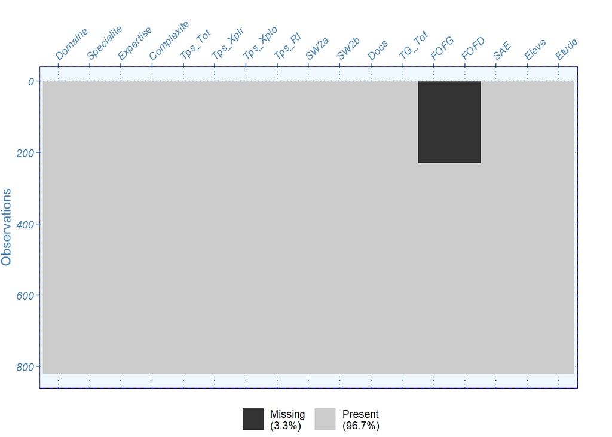

```r
library(visdat)
library(naniar)

# Représenter les données manquantes du dataset
vis_miss(test_heuristique, show_perc_col = FALSE, warn_large_data = FALSE) +
  theme(plot.margin = margin(0, 1, 0, 0, "cm")) +
  blue_theme()
```

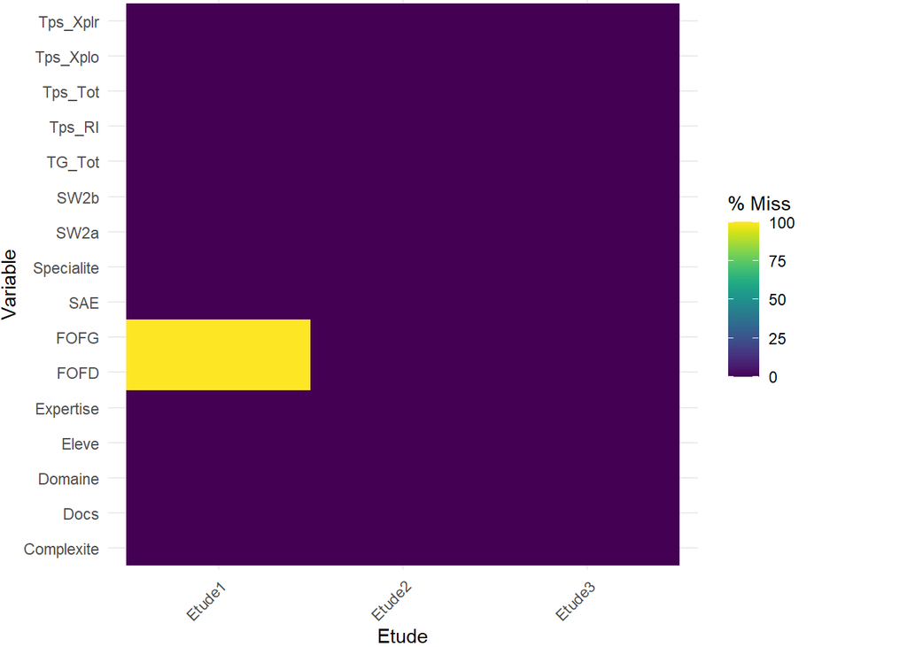

```r
gg_miss_fct(x = test_heuristique, fct = Etude) +
theme(plot.margin = margin(0, 2, 0, 0, "cm")) +
  labs(x = "Etude", y = "Variable", fill = "% de données manquantes")
```

Les 28% de NA proviennent de l’étude 1. Elles ne possèdent pas de structure particulière apparente, elles sont manquantes par “accident”. Cependant, pour les besoins de l’exercice nous allons réaliser une imputation par forêt aléatoire. En effet, l’idée est de nous servir des relations entre les informations expérimentales telles qu’éxistante (catégorielles et numériques) lors deux autres études, ce qui devrait permettre d’augmenter la puissance des tests statistiques à venir (augmentation de la taille de l’échantillon) sans trop altérer la structure de l’information disponible (Husson, 2017).

### Imputation des valeurs manquantes

```r
library(missForest)

MForest_df <- missForest(test_heuristique[, -c(16:17)]) # retrait des variables inutiles pour le traitement d'imputation
MForest_df$ximp
```

| Domaine | Specialite | Expertise | Complexite | Tps_Tot | Tps_Xplr | Tps_Xplo | Tps_RI | SW2a | SW2b | Docs | TG_Tot | FOFG | FOFD | SAE |
| --- | --- | --- | --- | --- | --- | --- | --- | --- | --- | --- | --- | --- | --- | --- |
| HIST | 3EME | expert | TC | 5.507825 | 4.403172 | 5.144327 | 5.216756 | 3.5000000 | 0.0000000 | 4.500000 | 0.028690185 | 3.730000 | 3.911667 | 19 |
| HIST | 3EME | expert | TC | 5.153318 | 4.913522 | 4.147553 | 4.982231 | 4.0000000 | 0.0000000 | 1.000000 | 0.142389292 | 3.002500 | 3.314952 | 45 |
| HIST | 3EME | expert | TC | 5.209855 | 4.858940 | 4.697378 | 5.086659 | 3.0000000 | 0.0000000 | 2.000000 | 0.040146938 | 2.921667 | 3.173167 | 33 |
| HIST | 3EME | expert | TC | 5.577592 | 4.270306 | 4.996023 | 5.070859 | 2.0000000 | 0.5000000 | 1.500000 | 0.040367954 | 3.090667 | 3.488773 | 45 |
| HIST | 3EME | expert | TC | 4.678682 | 3.832573 | 3.942058 | 4.191786 | 1.0000000 | 0.0000000 | 1.000000 | 0.228545309 | 1.996688 | 1.703452 | 45 |
| HIST | 3EME | expert | TC | 4.978833 | 4.481471 | 4.555252 | 4.820956 | 1.0000000 | 0.0000000 | 1.000000 | 0.055690140 | 3.098149 | 3.104952 | 39 |
| HIST | 3EME | expert | TC | 4.917203 | 3.880041 | 4.161218 | 4.344029 | 2.5000000 | 0.0000000 | 1.000000 | 0.275957227 | 2.130000 | 1.865119 | 49 |
| HIST | 3EME | expert | TC | 5.646339 | 4.841341 | 5.199511 | 5.357378 | 3.0000000 | 0.0000000 | 3.000000 | 0.012633361 | 2.798333 | 3.438301 | 49 |
| HIST | 3EME | expert | TC | 5.445337 | 4.827272 | 4.810669 | 5.120080 | 4.5000000 | 0.5000000 | 1.500000 | 0.061857264 | 3.393333 | 3.547106 | 44 |
| HIST | 3EME | expert | TC | 4.664971 | 3.966283 | 4.004794 | 4.286995 | 1.0000000 | 0.0000000 | 1.000000 | 0.197804371 | 2.897790 | 2.756524 | 41 |

[output cut: 809 more lines]

```r
# Remplacer les NA par les valeurs calculées
maj_imp <- function(original_df, imput_df, columns, num_rows) {
  for (col in columns) {
    # Identifier les lignes avec des valeurs manquantes
    NA_rows <- is.na(original_df[1:num_rows, col])

    # Reporter les valeurs imputées dans le df original
    original_df[1:num_rows, col][NA_rows] <- imput_df[NA_rows, col]
  }
  return(original_df)
}

# Utilisation de la fonction : remplacement des NA
colonnes_imp <- c("FOFG", "FOFD")
MForest_df$ximp$FOFG <- MForest_df$ximp$FOFG
MForest_df$ximp$FOFD <- MForest_df$ximp$FOFD
test_heuristique.imp <- maj_imp(test_heuristique, MForest_df$ximp, colonnes_imp, 228)
```

### Qualité de l’imputation (aperçu)

```r
# Ajoutez une colonne pour identifier les dataframes avant/après imputation
test_heuristique$Source <- "Original"
test_heuristique.imp$Source <- "Imputation_RF"

comb_df <- rbind(test_heuristique, test_heuristique.imp)
```

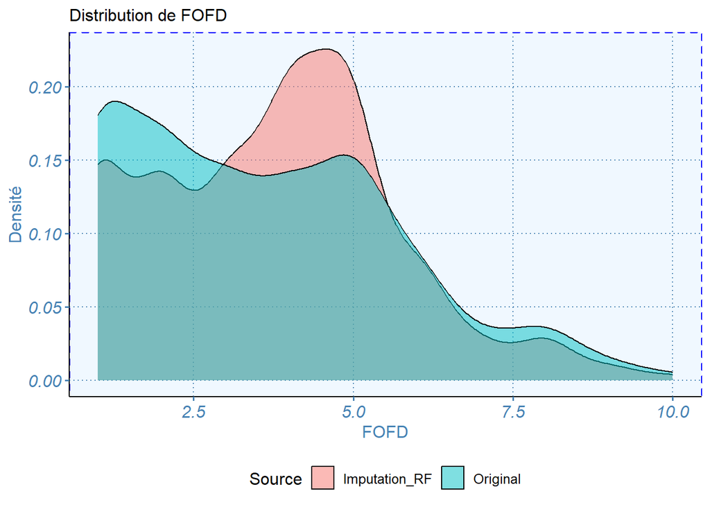

```r
dens1 <- ggdensity(comb_df, x = "FOFD", fill = "Source") +
  labs(subtitle = "Distribution de FOFD",
       x = "FOFD",
       y = "Densité") +
  blue_theme()
dens1
```

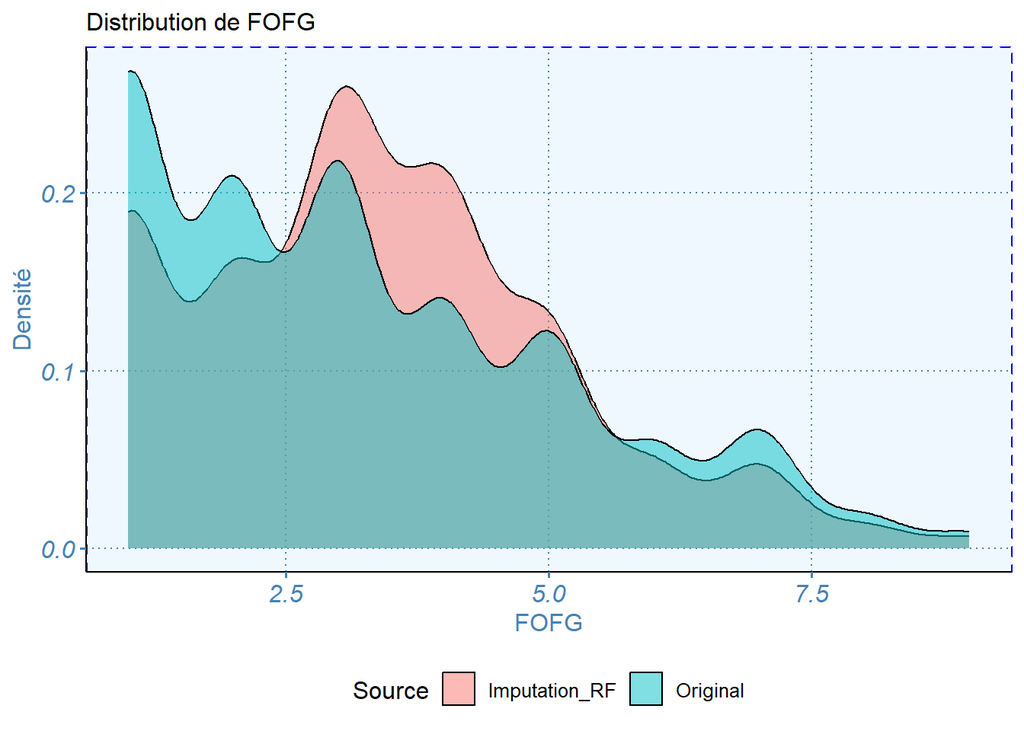

```r
dens2 <- ggdensity(comb_df, x = "FOFG", fill = "Source") +
  labs(subtitle = "Distribution de FOFG",
       x = "FOFG",
       y = "Densité") +
  blue_theme()
dens2
```

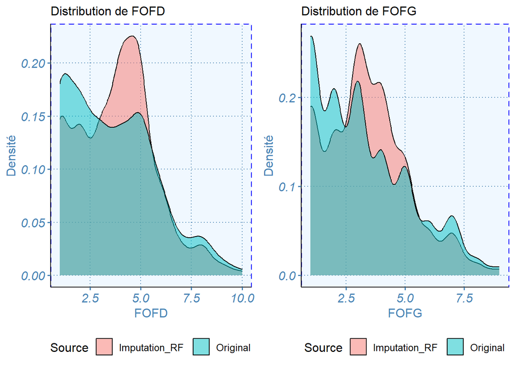

```r
ggarrange(dens1, dens2)
```

L’imputation par forêts aléatoire semble ne pas avoir trop déformé la distribution des mesures métacognitives, permettant même une distribution de ces variables plus proche d’une loi normale.

# Analyse exploratoire

J’ai étudié la variable cible (temps d’arrêt ou Tps_Tot) et les caractéristiques de l’activité des élèves tels que requis par l’analyse demandée (ici le nombre de documents, Docs, et le taux d’information pertinente accumulée, ou TG_Tot), ainsi que la relation entre la variable cible et ces caractéristiques. Après l’analyse, j’ai décidé d’appliquer les changements suivants pour permettre la modélisation :

- TG_Tot : utiliser la transformation 1/x
- Docs : Créer une nouvelle variable catégorielle (ordinale) à partir de la variable numérique d’origine

## Préambule : indicateurs de dispersions des principales variables numériques utilisées

```r
# Exploration des variables numériques
variables_a_explorer <- test_heuristique.imp %>%
  select("TG_Tot", "Docs", "Tps_Tot", "FOFD", "FOFG", "Expertise") %>%
  get_summary_stats(type = "mean_sd")
variables_a_explorer
```

| variable | n | mean | sd |
| --- | --- | --- | --- |
| TG_Tot | 819 | 0.029 | 0.064 |
| Docs | 819 | 2.527 | 1.765 |
| Tps_Tot | 819 | 5.460 | 0.304 |
| FOFD | 819 | 3.760 | 1.897 |
| FOFG | 819 | 3.359 | 1.743 |

```r
# Exploration des variables numériques par groupe d'expertise
variables_a_explorer.g <- test_heuristique.imp %>%
  select("TG_Tot", "Docs", "Tps_Tot", "FOFD", "FOFG", "Expertise") %>%
  group_by(Expertise) %>%
  get_summary_stats(type = "mean_sd")
variables_a_explorer.g
```

| Expertise | variable | n | mean | sd |
| --- | --- | --- | --- | --- |
| expert | TG_Tot | 408 | 0.034 | 0.062 |
| expert | Docs | 408 | 2.487 | 1.765 |
| expert | Tps_Tot | 408 | 5.456 | 0.298 |
| expert | FOFD | 408 | 3.389 | 1.751 |
| expert | FOFG | 408 | 2.929 | 1.631 |
| novice | TG_Tot | 411 | 0.025 | 0.065 |
| novice | Docs | 411 | 2.567 | 1.766 |
| novice | Tps_Tot | 411 | 5.464 | 0.310 |
| novice | FOFD | 411 | 4.128 | 1.966 |
| novice | FOFG | 411 | 3.786 | 1.748 |

```r
variables_a_explorer.gc <- test_heuristique.imp %>%
  select("TG_Tot", "Docs", "Tps_Tot", "FOFD", "FOFG", "Expertise", "Complexite") %>%
  group_by(Expertise, Complexite) %>%
  get_summary_stats(type = "mean_sd")
variables_a_explorer.gc
```

| Expertise | Complexite | variable | n | mean | sd |
| --- | --- | --- | --- | --- | --- |
| expert | TC | TG_Tot | 160 | 0.064 | 0.088 |
| expert | TC | Docs | 160 | 1.649 | 0.960 |
| expert | TC | Tps_Tot | 160 | 5.274 | 0.313 |
| expert | TC | FOFD | 160 | 2.325 | 1.268 |
| expert | TC | FOFG | 160 | 2.331 | 1.364 |
| expert | TI | TG_Tot | 124 | 0.013 | 0.013 |
| expert | TI | Docs | 124 | 3.427 | 2.104 |
| expert | TI | Tps_Tot | 124 | 5.600 | 0.210 |
| expert | TI | FOFD | 124 | 4.369 | 1.639 |
| expert | TI | FOFG | 124 | 3.665 | 1.711 |

[output cut: 20 more lines]

## Exploration de la variable cible : le temps d’arrêt

A partir de l’analyse des histogrammes ci-dessous, la variable cible semble globalement soutenir l’hypothèse de normalité, quelque soit le facteur experimental (Expertise ou Complexité). Pas de transformation envisagée. On note le possible effet de l’incertitude (mesuré par complexité des tâches) ; pas d’effet remarquable des connaissances antérieures (niveau d’expertise)

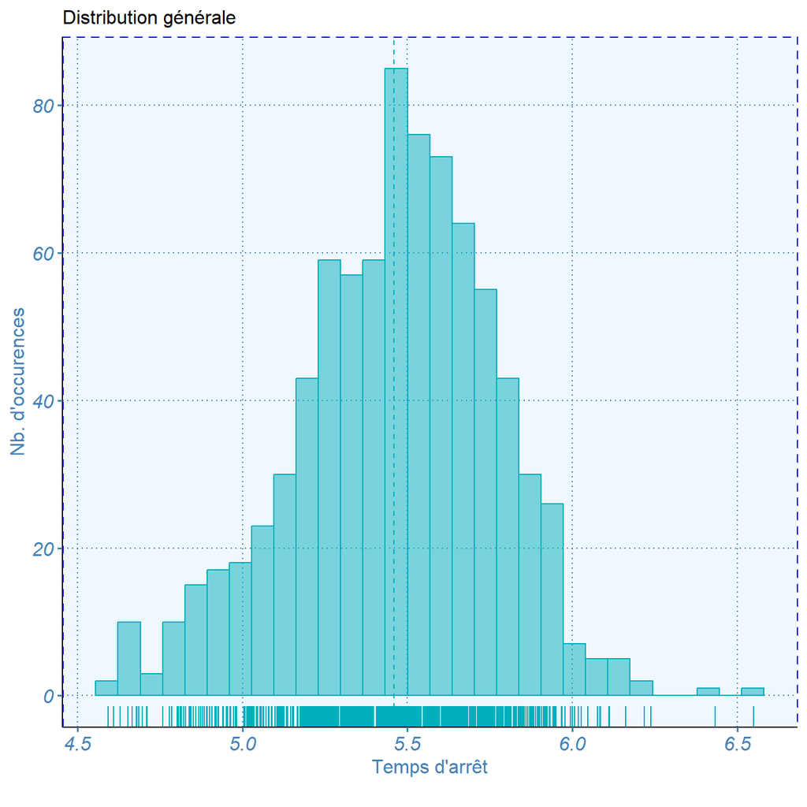

```r
# Distribution de Tps_Tot
dist_y <- gghistogram(test_heuristique.imp, x = "Tps_Tot",
   add = "mean", rug = TRUE, color = "#00AFBB", fill = "#00AFBB") +
   labs(subtitle = "Distribution générale",
       x = "Temps d'arrêt\n",
       y = "Nb. d'occurences") +
  blue_theme()
dist_y
```

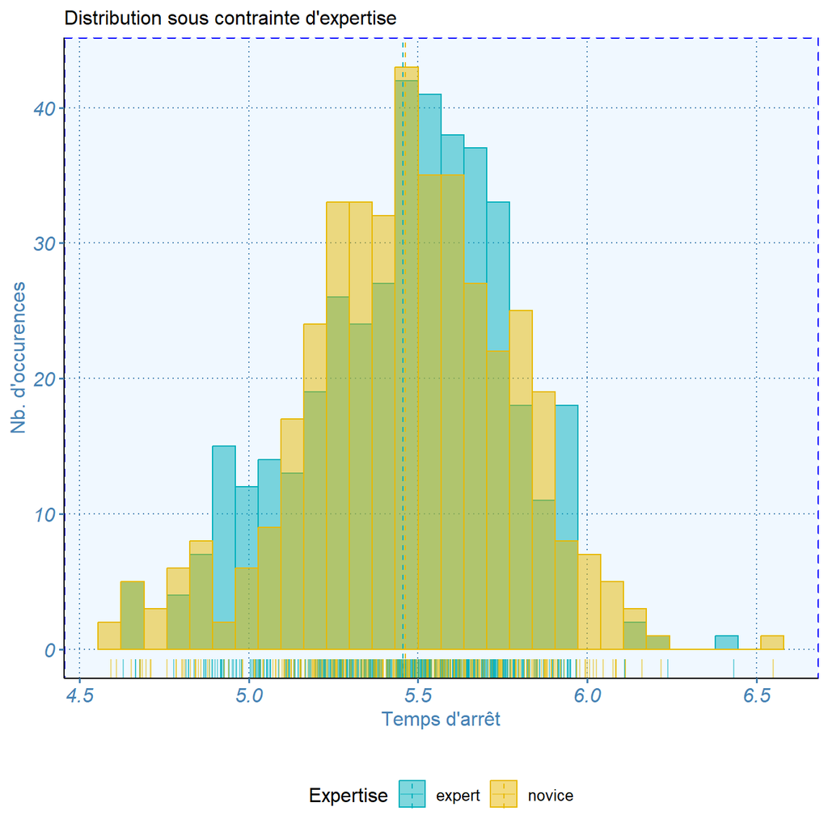

```r
# Introudction des facteurs experimentaux
dist_y.f1 <- gghistogram(test_heuristique.imp, x = "Tps_Tot",
   add = "mean", rug = TRUE,
   color = "Expertise", fill = "Expertise",
   palette = c("#00AFBB", "#E7B800")) +
   labs(subtitle = "Distribution sous contrainte d'expertise",
       x = "Temps d'arrêt\n",
       y = "Nb. d'occurences") +
  blue_theme()
dist_y.f1
```

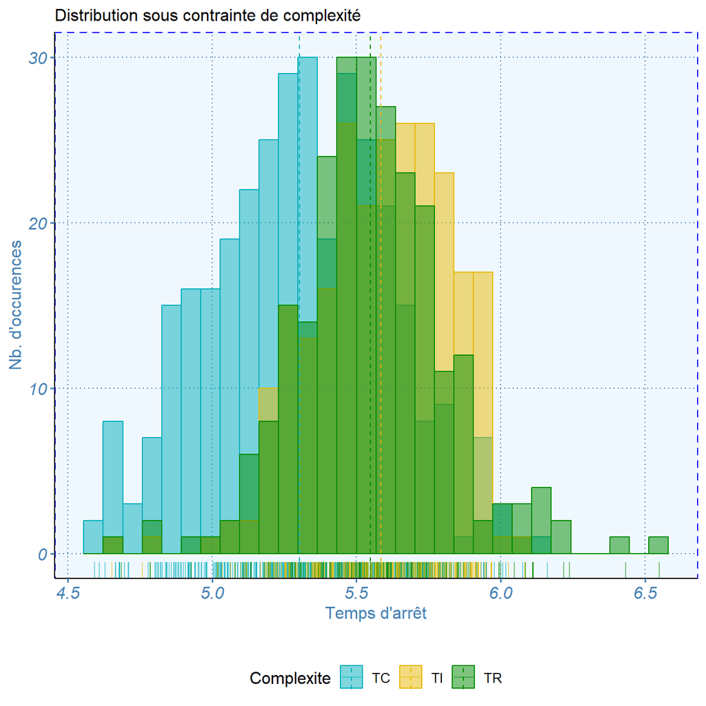

```r
dist_y.f2 <- gghistogram(test_heuristique.imp, x = "Tps_Tot",
   add = "mean", rug = TRUE,
   color = "Complexite", fill = "Complexite",
   palette = c("#00AFBB", "#E7B800", "green4" )) +
   labs(subtitle = "Distribution sous contrainte de complexité",
       x = "Temps d'arrêt\n",
       y = "Nb. d'occurences") +
  blue_theme()
dist_y.f2
```

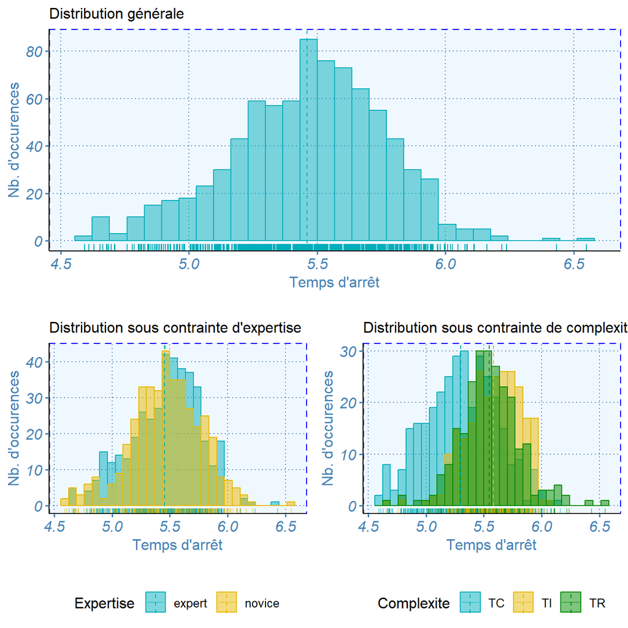

```r
ggarrange(dist_y,
          ggarrange(dist_y.f1, dist_y.f2, ncol = 2),
          ncol = 1, nrow = 2)
```

On observe une modification de la distribution du temps d’arrêt selon la complexité des tâches (plus de valeurs différentes selon les modalités de complexité) traduisant une plus grande variabilité des valeurs. Cette variabilité plus importante soulignent l’effet de l’incertitude sur le temps d’arrêt, traduisant des comportements différentes chez les utilisateurs. On note également une augmentation du temps d’arrêt avec la complexité des tâches. A contrario, on ne remarquez pas d’effet de l’expertise sur le temps d’arrêt dans la représentation de la distribution ci-dessus, traduisant une certaine stabilité des comportements des utilisateurs, quelque soit leur niveau d’expertise.

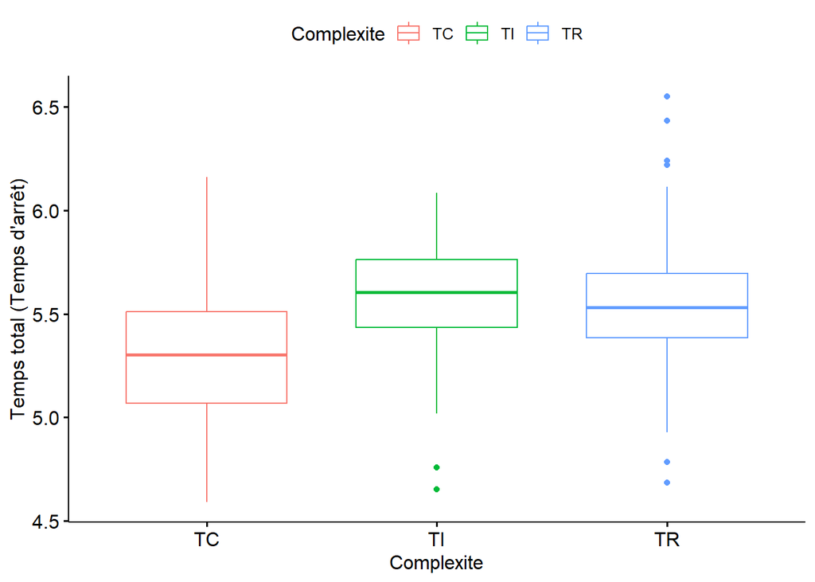

```r
# Boxplots du Temps d'arrêt versus Complexité
box1 <- ggboxplot(test_heuristique.imp, x = "Complexite", y = "Tps_Tot",
                  color = "Complexite") +
  ylab("Temps total (Temps d'arrêt)")
box1
```

On peut s’attendre à un effet de la complexité (entre TC-TI et TC-TR), signifiant une modification des comportement lors de l’augmentation de la complexité des tâches (TC = tâches contrôles sans incertitude), mais pas de différence entre les deux modalités des tâches complexes.

[figure not shown]

```r
# Moyenne et écart-type du temps d'arrêt versus expertise
 ggerrorplot(test_heuristique.imp, x = "Expertise", y = "Tps_Tot",
 color = "Expertise", palette = c("blue", "#E7B800"),
 error.plot = "pointrange",
 position = position_dodge(0.5),
 orientation = "horizontal") +
  labs(subtitle = "Moyenne et écart-type du temps d'arrêt selon l'expertise") +
  blue_theme()
```

Bien qu’il puissse exister une difference dans les moyennes de temps d’arrêt entre les deux groupes (expert vs novice), cette différence semble manifestement trop faible (et trop dispersée) pour permettre la mesure ultérieure d’un effet significatif de l’expertise. Nous nous attendons donc à l’absence d’un effet significatif de l’expertise dans les analyses ultérieures.

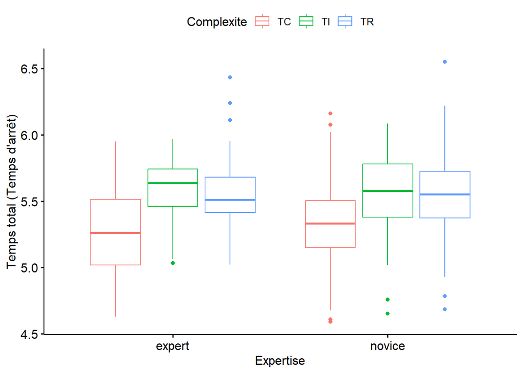

```r
# Boxplots du Temps d'arrêt versus Expertise + Complexite (exploration des interactions)
box2 <- ggboxplot(test_heuristique.imp, x = "Expertise", y = "Tps_Tot",
                  color = "Complexite") +
  ylab("Temps total (Temps d'arrêt)")
box2
```

## Variables liées aux caractéristiques de l’activité de recherche (nombre de documents - Docs - et taux d’information pertinente accumulée - TG_Tot) et leurs relations avec la variables cibles

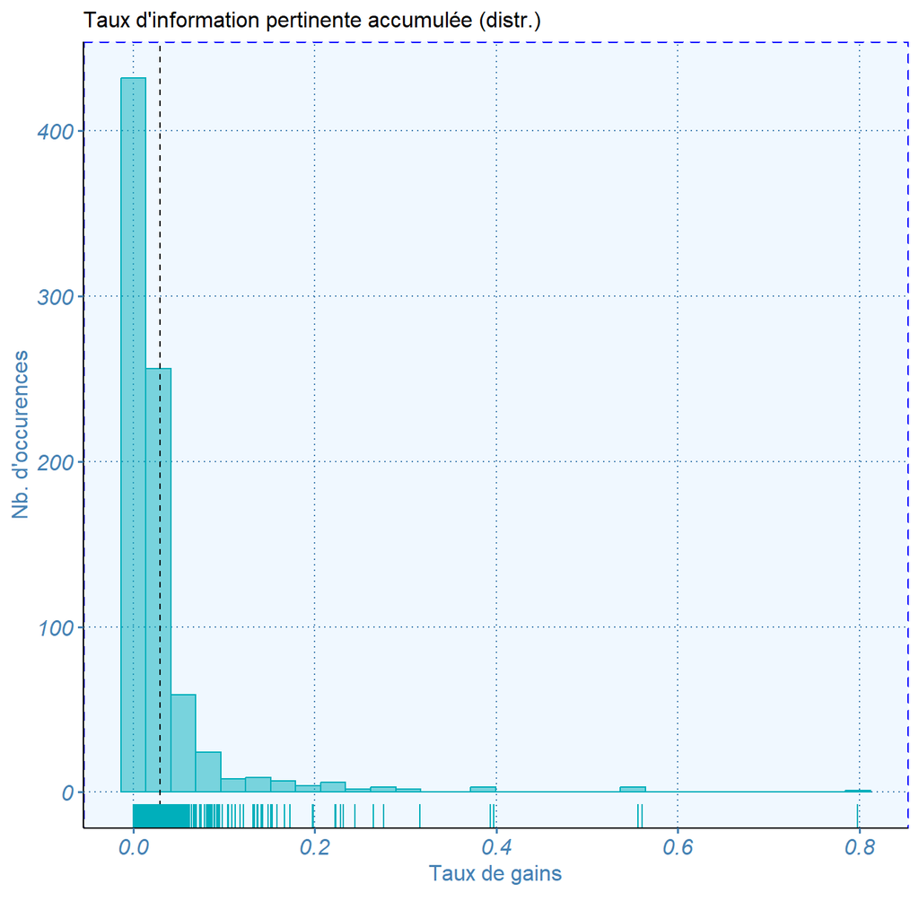

```r
# Distribution de TG_Tot
dist_TG_Tot <- gghistogram(test_heuristique.imp, x = "TG_Tot",
   add = "mean", rug = TRUE, color = "#00AFBB", fill = "#00AFBB",
   add.params = list(color = "black", linetype = "dashed")) +
   labs(subtitle = "Taux d'information pertinente accumulée (distr.)",
       x = "Taux de gains\n",
       y = "Nb. d'occurences") +
  blue_theme()
dist_TG_Tot
```

```r
# Ajuster la distribution : transformer la variable
test_heuristique.imp$TG_Tot_t <- 1/(test_heuristique.imp$TG_Tot)

# Calcul de la moyenne en excluant les valeurs Inf et NA
mean_TG_Tot_t <- mean(replace(test_heuristique.imp$TG_Tot_t, test_heuristique.imp$TG_Tot_t == Inf, NA), na.rm = TRUE)
mean_TG_Tot_t
```

```
## [1] 82.81704
```

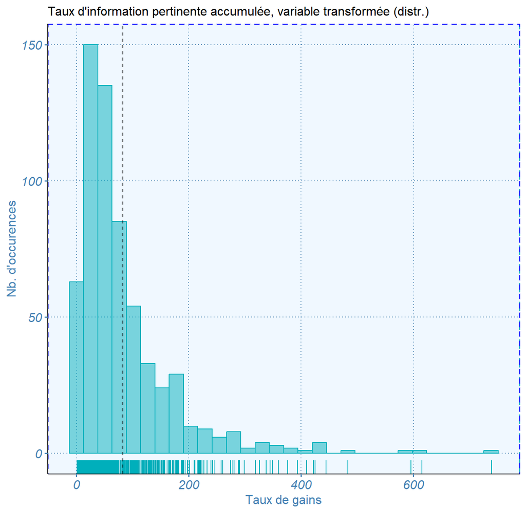

```r
dist_TG_Tot_t <- gghistogram(test_heuristique.imp, x = "TG_Tot_t",
   add = "mean", rug = TRUE, color = "#00AFBB", fill = "#00AFBB") +
   geom_vline(xintercept = mean_TG_Tot_t, linetype = "dashed", color = "black") +
   labs(subtitle = "Taux d'information pertinente accumulée, variable transformée (distr.)",
       x = "Taux de gains\n",
       y = "Nb. d'occurences") +
  blue_theme()
dist_TG_Tot_t
```

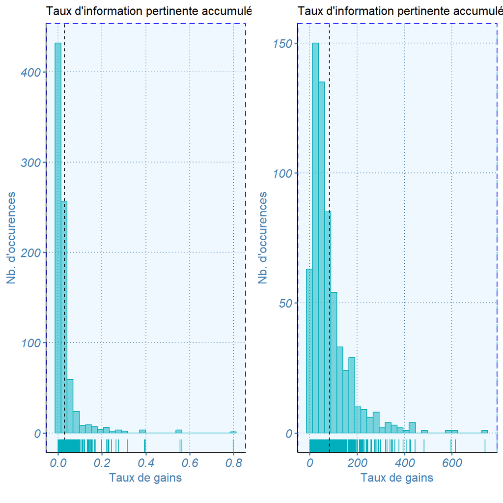

```r
ggarrange(dist_TG_Tot, dist_TG_Tot_t)
```

Le resserrement des valeurs autour de 0 (modalité de calcul liée au cadre théorique de l’expérimentation) gêne consédérablement les transformations, faisant apparaître des valeurs “infinies” pour certaines transformations. La transformartion 1/x permet un meilleur étalement, et pourra être utilisée.

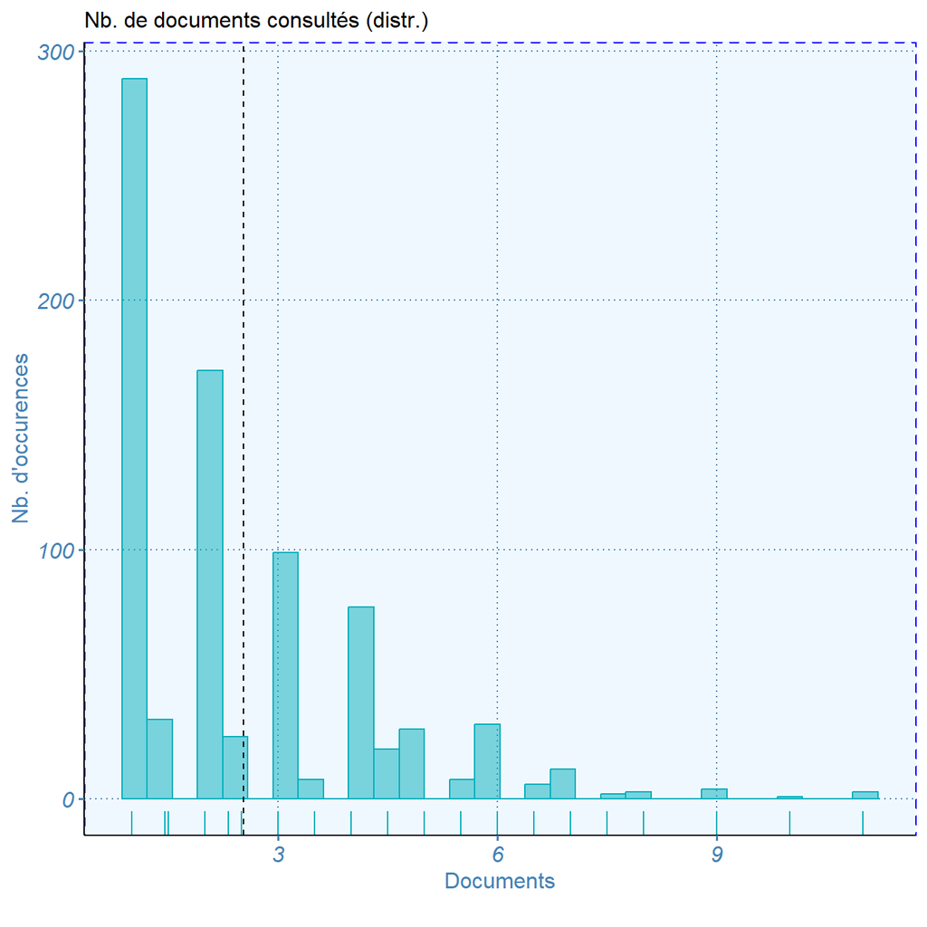

```r
# Distribution de Docs
dist_Docs <- gghistogram(test_heuristique.imp, x = "Docs",
   add = "mean", rug = TRUE, color = "#00AFBB", fill = "#00AFBB",
   add.params = list(color = "black", linetype = "dashed")) +
   labs(subtitle = "Nb. de documents consultés (distr.)",
       x = "Documents\n",
       y = "Nb. d'occurences") +
  blue_theme()
dist_Docs
```

La distribution des documents n’est pas continue, des groupements apparaissent dans les données et peut amener à discrétiser cette variable.

## Liaison entre variable cible et facteurs d’intérêts

### Analyse des corrélations

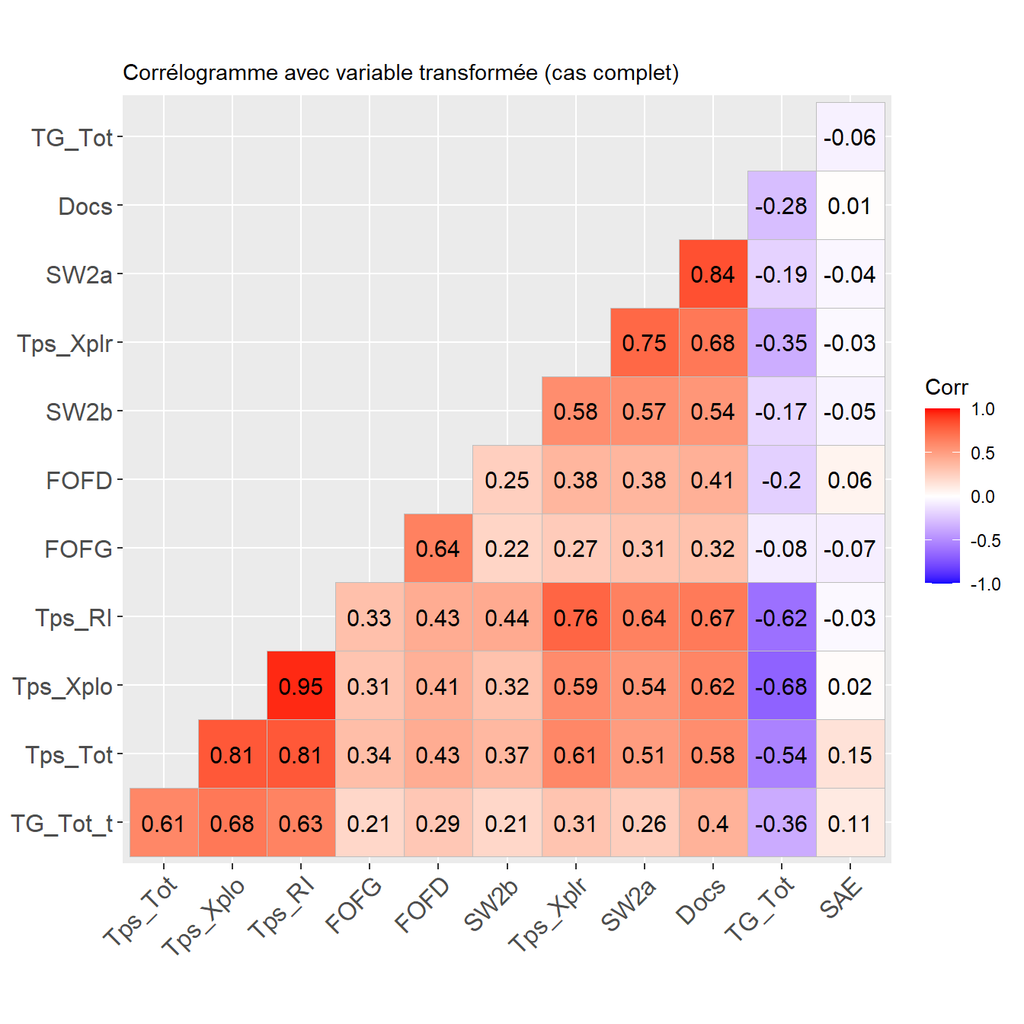

```r
library(ggcorrplot)
library(corrplot)
library(GGally)

# Construction de la matrice des corrélation pour les variables numériques + variable transformée
cor_df <- test_heuristique.imp %>%
  select_if(is.numeric) %>%
  mutate_all(~replace(., . == Inf, NA)) %>%  # Remplacer Inf par NA (cas de la variable transformée)
  cor(use = "complete.obs")  # Utiliser seulement les observations complètes pour le calcul de corrélation

cor_df2 <- test_heuristique.imp[,-19] %>% # Retrait de la variable transformée
  select_if(is.numeric)
cor_df2 <- cor(cor_df2)


# Construtcion de la heatmap1
corplot1 <- ggcorrplot(cor_df, hc.order = TRUE, type = "lower",
   lab = TRUE, ggtheme = theme_gray) +
  labs(subtitle = "Corrélogramme avec variable transformée (cas complet)")
corplot1
```

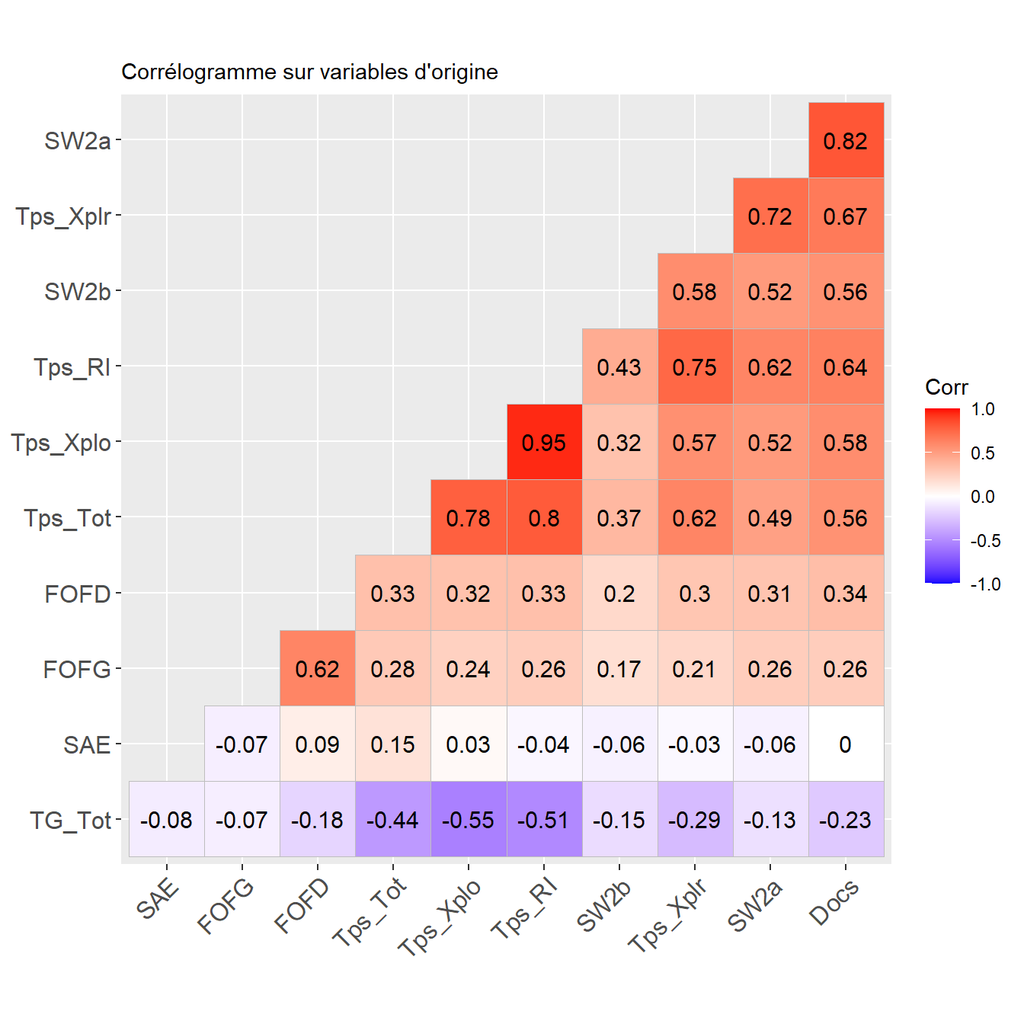

```r
# Construtcion de la heatmap2
corplot2 <- ggcorrplot(cor_df2, hc.order = TRUE, type = "lower",
   lab = TRUE, ggtheme = theme_gray) +
  labs(subtitle = "Corrélogramme sur variables d'origine")
corplot2
```

[figure not shown]

```r
ggarrange(corplot1, corplot2)
```

### Scatterplots

Pour confirmer ces relations linéaires, j’ai réalisé des scatterplots entre les variables numériques. Les scatterplots ci-dessous soutiennent les relations linéaires entre Tps_Tot et TG_Tot (souligné par TG_Tot_t), ainsi qu’entre Docs et Tps_Tot, mais montrent qu’il est possible de considérer des “groupements” pour Docs. Une discrétisation de cette variable est donc proposée.

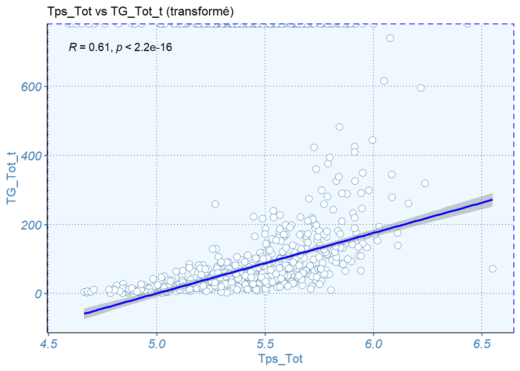

```r
#Scatterplot Tps_tot vs TG_Tot_t"
scat1 <- ggscatter(test_heuristique.imp, x = "Tps_Tot", y = "TG_Tot_t",
          color = "steelblue", shape = 21, size = 3,
          add = "reg.line",
          add.params = list(color = "blue", fill = "gray50"),
          conf.int = TRUE,
          cor.coef = TRUE, cor.method = "pearson"
          ) +
  labs(subtitle = "Tps_Tot vs TG_Tot_t (transformé)") +
  blue_theme()

scat1
```

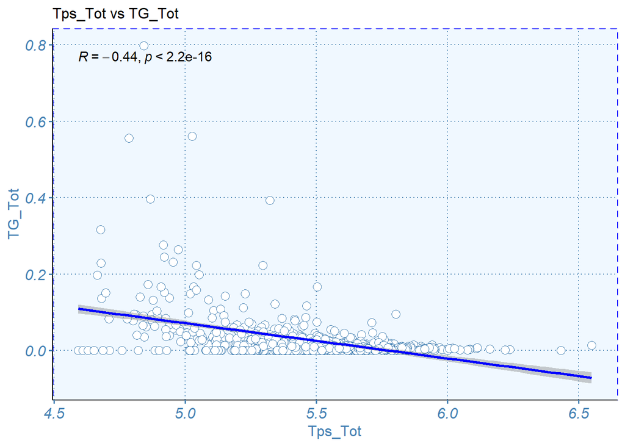

```r
#Scatterplot Tps_tot vs TG_Tot"
scat1b <- ggscatter(test_heuristique.imp, x = "Tps_Tot", y = "TG_Tot",
          color = "steelblue", shape = 21, size = 3,
          add = "reg.line",
          add.params = list(color = "blue", fill = "gray50"),
          conf.int = TRUE,
          cor.coef = TRUE, cor.method = "pearson"
          ) +
  labs(subtitle = "Tps_Tot vs TG_Tot") +
  blue_theme()

scat1b
```

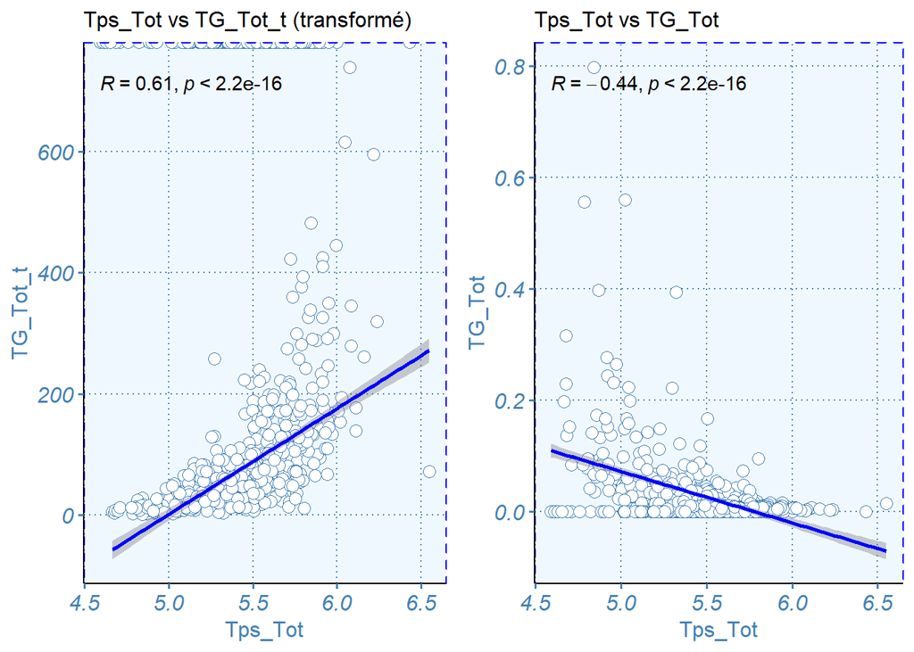

```r
ggarrange(scat1, scat1b)
```

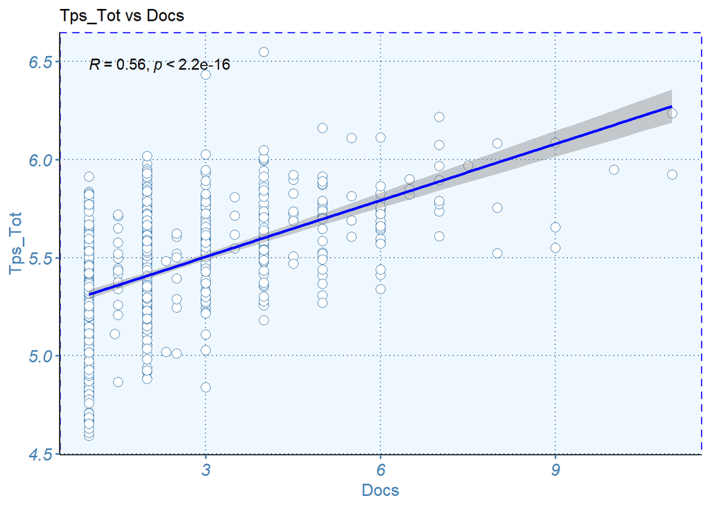

```r
#Scatterplot Tps_tot vs Docs"
scat2 <- ggscatter(test_heuristique.imp, x = "Docs", y = "Tps_Tot",
          color = "steelblue", shape = 21, size = 3,
          add = "reg.line",
          add.params = list(color = "blue", fill = "gray50"),
          conf.int = TRUE,
          cor.coef = TRUE, cor.method = "pearson"
          ) +
  labs(subtitle = "Tps_Tot vs Docs") +
  blue_theme()
scat2
```

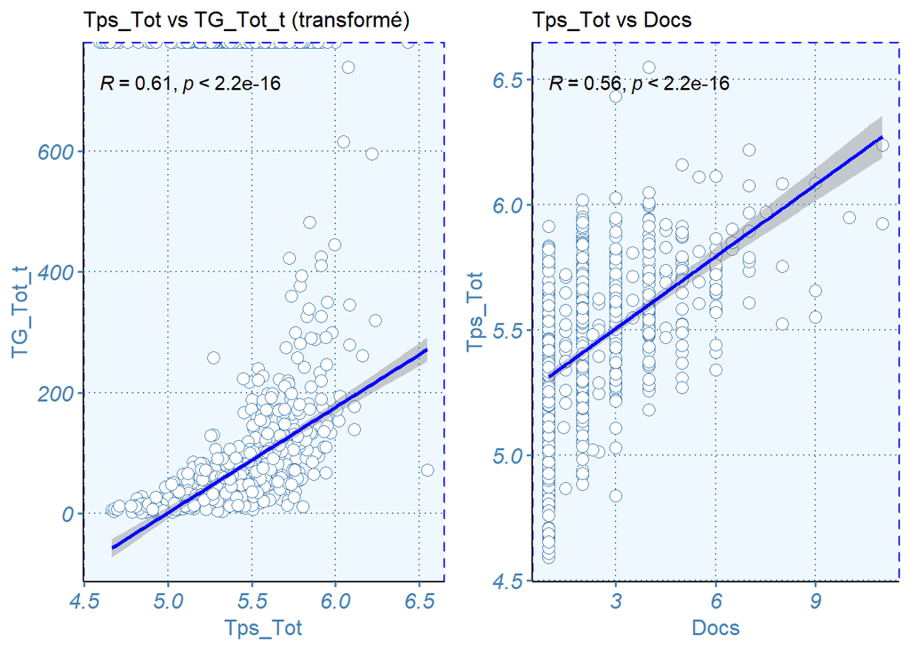

```r
# Figure combinée
ggarrange(scat1, scat2)
```

La discrétisation, pratique courante en analyse de données, n’est à strictement parlé, pas nécessaire si la relation est linéaire avec la variable cible. Elle permet toutefois d’autres analyse et exploration

```r
# Discrétisation de la variable Docs
tab1 <- table(as.factor(test_heuristique.imp$Docs))
tab1_str <- capture.output(print(tab1))
writeClipboard(tab1_str)

test_heuristique.imp$c.Docs <- cut(test_heuristique.imp$Docs, c(0,1,2,3,Inf))
table(test_heuristique.imp$c.Docs)
```

```
##
##   (0,1]   (1,2]   (2,3] (3,Inf]
##     289     204     124     202
```

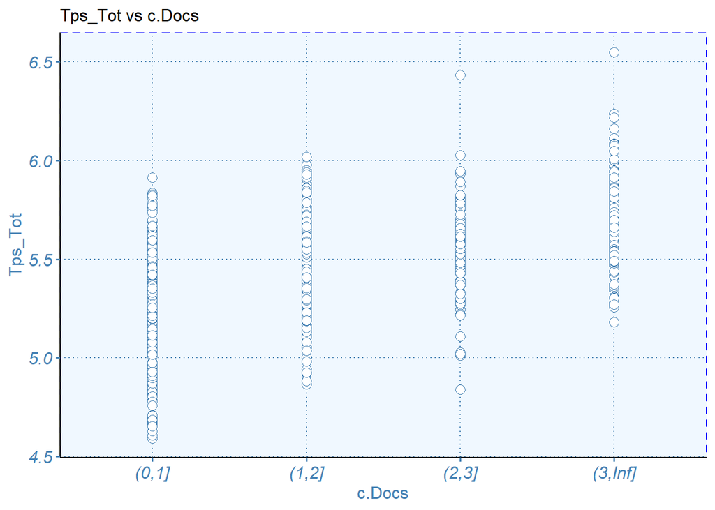

```r
scat3 <- ggscatter(test_heuristique.imp, x = "c.Docs", y = "Tps_Tot",
          color = "steelblue", shape = 21, size = 3) +
  labs(subtitle = "Tps_Tot vs c.Docs") +
  blue_theme()
scat3
```

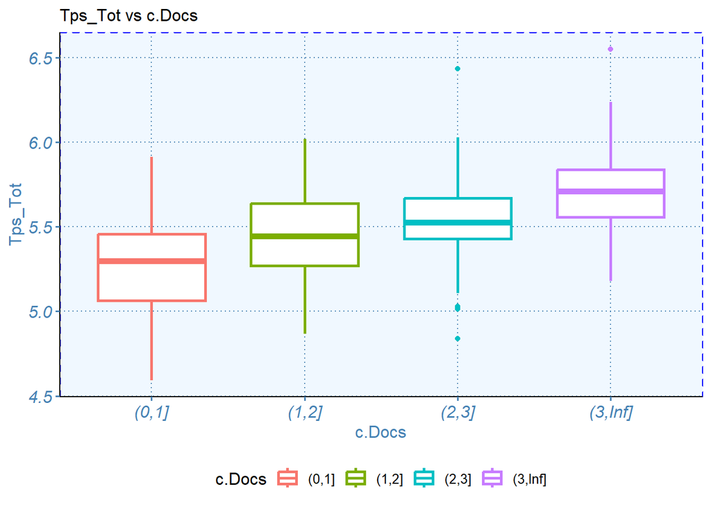

```r
box3 <- ggboxplot(test_heuristique.imp, x = "c.Docs", y = "Tps_Tot",
          color = "c.Docs", shape = 1, size = 1,
          conf.int = TRUE) +
  labs(subtitle = "Tps_Tot vs c.Docs") +
  blue_theme()
box3
```

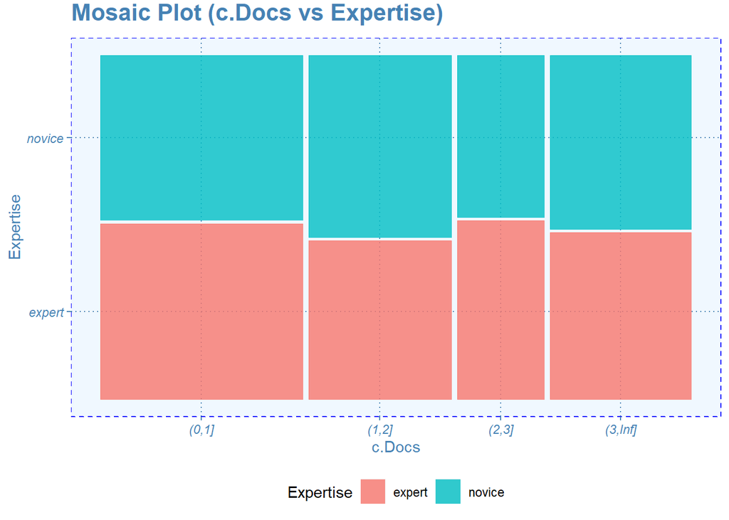

```r
# Exemple de traitement possible sur la variable c.Docs
library(ggmosaic)

# mozaicplot expertise/nb de document
mosaic_plot <- ggplot(data = test_heuristique.imp) +
  geom_mosaic(aes(x = product(c.Docs), fill = Expertise)) +
  labs(y = "Expertise", x = "c.Docs", title = "Mosaic Plot (c.Docs vs Expertise)") +
  blue_theme()
mosaic_plot
```

### Analyse multidimensionnelles des relations entre variables (ACP et AFM)

Parce qu’un corrélogramme ne peut que saisir les relations bivariées (e.g. par paire) entre variables, et que nous souhaitons construire un modèle dans lequel les deux variables TG_Tot et Docs puissent prédire et expliquer simultanément le temps total ou temps d’arrêt (Tps_Tot), il nous semble intéressant de produire des visualisations permettant de représenter ces liaisons multiples.

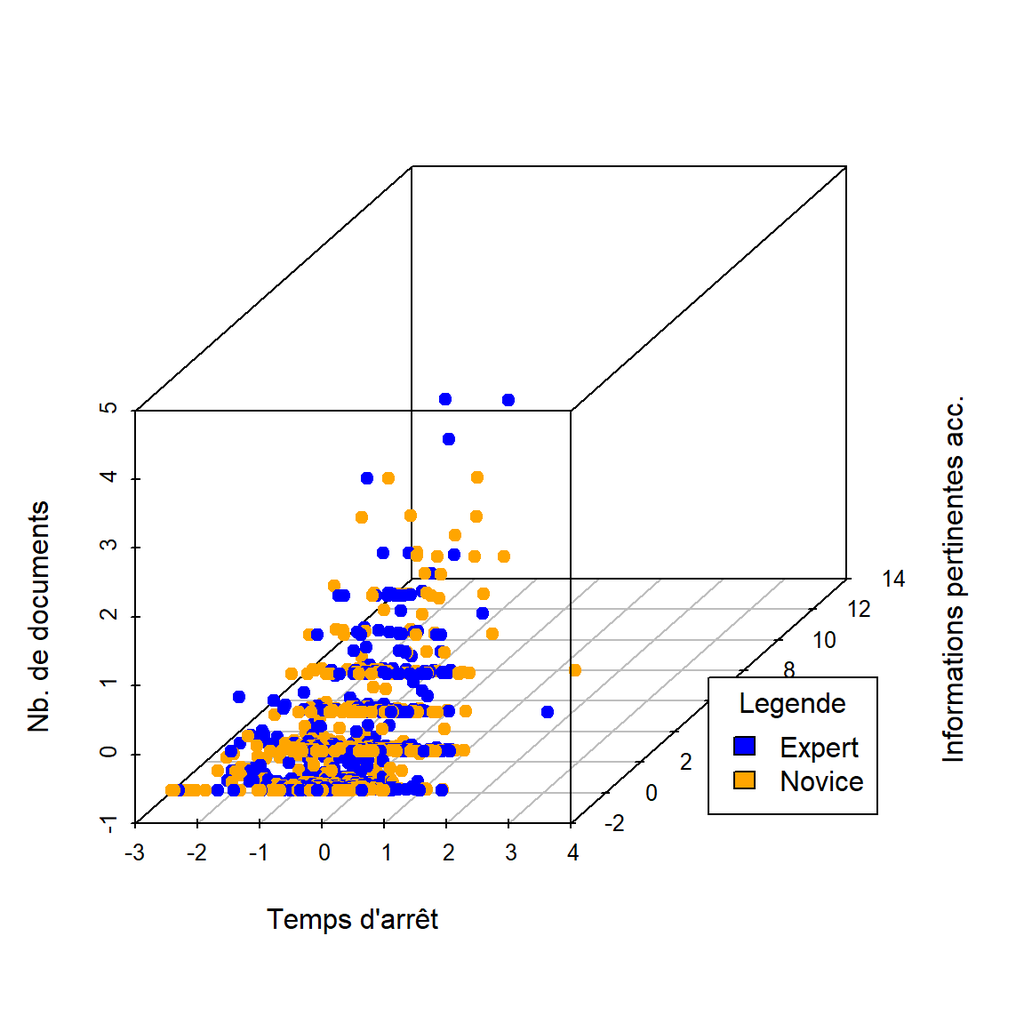

```r
library(scatterplot3d)

# Assignation des couleurs
colors <- c("blue", "orange")
plot_colors <- colors[test_heuristique.imp$Expertise]



# scatterplot 3d
test_heuristique.imp_scale <- scale(test_heuristique.imp[, c("Tps_Tot", "TG_Tot", "Docs")])

x <- test_heuristique.imp_scale[,1]
y <- test_heuristique.imp_scale[,2]
z <- test_heuristique.imp_scale[,3]

xlabel <- paste("Temps d'arrêt")
ylabel <- paste("Informations pertinentes acc.")
zlabel <- paste("Nb. de documents")


scatterplot3d(x,y,z, xlab = xlabel, ylab = ylabel, zlab = zlabel, color = plot_colors, pch = 19)

# Ajout de la légende
legend("bottomright", inset=.05, title="Legende", c("Expert", "Novice"), fill=colors)
```

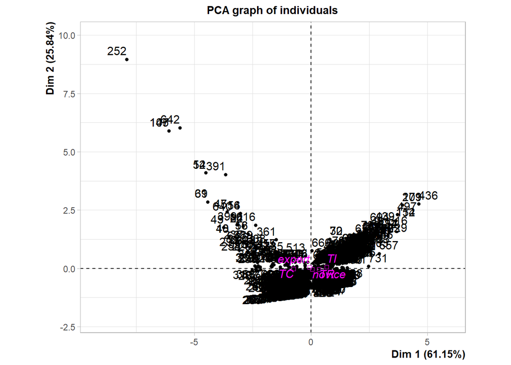

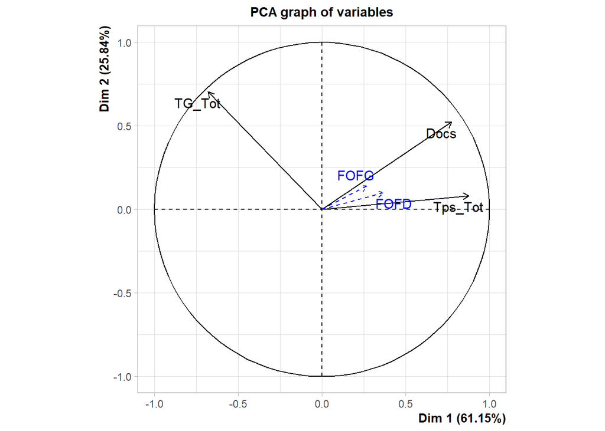

```r
library(FactoMineR)

multi.var <- test_heuristique.imp %>%
  select("Tps_Tot", "Docs", "Expertise", "Complexite", "TG_Tot", "FOFG", "FOFD")

#ACP
res.acp <- PCA(multi.var, quanti.sup = c("FOFD", "FOFG"), quali.sup=c("Expertise", "Complexite"), scale.unit=TRUE, graph=TRUE)
```

Cette représentation montre la relation entre TG_Tot et Docs dans le cadre de l’analyse des trois variables, qui semblent bien manifester une relation complémentaire “en sens inverse” l’une de l’autre.Les jugements métacognitifs, mal représentés sur le plan factoriel, pourraient effectivement avoir un pouvoir prédictif du nombre de documents et du temps (FOFG), mais ces effets devraient être de faible puissance.

# Résultats : modèle(s) et vérification des hypothèses

## Verification des hypothèses

### Heuristique TG_Tot et Docs sur Tps_Tot + effets des facteurs expérimentaux

```r
library(stats)

# Régression linéaire
model.reg <- lm(scale(Tps_Tot) ~ scale(TG_Tot) + scale(Docs) + Expertise + Complexite + Expertise*Complexite, test_heuristique.imp)

# Affichage du résumé du modèle
summary(model.reg)
```

```
##
## Call:
## lm(formula = scale(Tps_Tot) ~ scale(TG_Tot) + scale(Docs) + Expertise +
##     Complexite + Expertise * Complexite, data = test_heuristique.imp)
##
## Residuals:
##      Min       1Q   Median       3Q      Max
## -2.52995 -0.48203  0.00724  0.47432  2.98751
##
## Coefficients:
##                                Estimate Std. Error t value Pr(>|t|)
## (Intercept)                  -0.2437064  0.0620661  -3.927 9.35e-05 ***
## scale(TG_Tot)                -0.2860547  0.0277938 -10.292  < 2e-16 ***
## scale(Docs)                   0.4238375  0.0283709  14.939  < 2e-16 ***
## Expertisenovice               0.0008241  0.0828234   0.010    0.992
## ComplexiteTI                  0.4175303  0.0954441   4.375 1.38e-05 ***
## ComplexiteTR                  0.4413503  0.0926000   4.766 2.22e-06 ***
## Expertisenovice:ComplexiteTI -0.0633681  0.1264784  -0.501    0.616
## Expertisenovice:ComplexiteTR -0.0225487  0.1266027  -0.178    0.859
## ---
## Signif. codes:  0 '***' 0.001 '**' 0.01 '*' 0.05 '.' 0.1 ' ' 1
##
## Residual standard error: 0.7463 on 811 degrees of freedom
## Multiple R-squared:  0.4479, Adjusted R-squared:  0.4431
## F-statistic: 93.98 on 7 and 811 DF,  p-value: < 2.2e-16
```

```r
# Tableau d'analyse de variance
anova(model.reg)
```

|  | Df | Sum Sq | Mean Sq | F value | Pr(>F) |
| --- | --- | --- | --- | --- | --- |
| scale(TG_Tot) | 1 | 159.3251202 | 159.32512023 | 286.0899237 | 3.368200e-55 |
| scale(Docs) | 1 | 178.7772123 | 178.77721226 | 321.0188007 | 9.770653e-61 |
| Expertise | 1 | 0.3877821 | 0.38778211 | 0.6963155 | 4.042702e-01 |
| Complexite | 2 | 27.7186664 | 13.85933320 | 24.8863178 | 3.241075e-11 |
| Expertise:Complexite | 2 | 0.1406651 | 0.07033256 | 0.1262917 | 8.813751e-01 |
| Residuals | 811 | 451.6505539 | 0.55690574 | NA | NA |

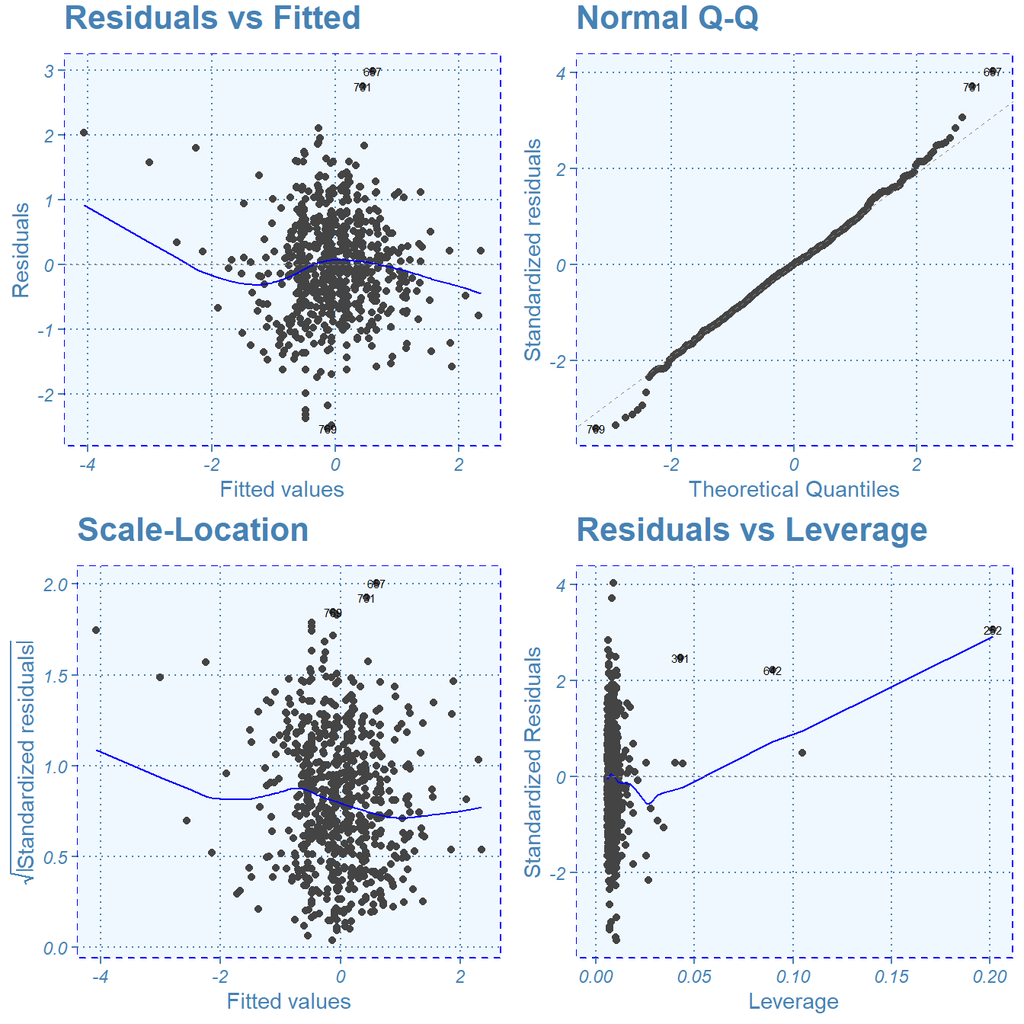

```r
# Créer des graphiques de diagnostic
library(ggfortify)

autoplot(model.reg, which = c(1:3,5), nrow = 2, ncol = 2, label.size = 2) +
  blue_theme()
```

Comme le souligne les résultats de la régression linéaire multiple, le taux de gain et le nombre de documents ont un effet sur le temps d’arrêts des élèves, et représentent des prédicteurs significatifs de la décision d’arrêt, confirmant notre hypothèse. La complexité montre également un effet sur la temps d’arrêt, permettant de confirmer notre hypothèse, mais pas l’expertise (niveau de connaissances antérieures), invalidant notre hypothèse.